# Single-cell ATAC-seq, Session 4

Bioinformatics Resource Center - Rockefeller University

http://rockefelleruniversity.github.io/scATAC/

brc@rockefeller.edu

## Overview

- Differential Accessibility Analysis
- FindMarkers for scATAC-seq
- Visualizing regions of interest
- QC and Markers
- Pseudobulk differential accessibility
- Where to Go Next

# Differential Accessibility Analysis

## What is Differential Accessibility?

Having annotated our clusters, a common next question is:

**Which genomic regions are more accessible in cell type A than cell type B?**

Differentially accessible (DA) peaks can point to:

- **Cell-type-specific regulatory elements** — enhancers and promoters active only in certain populations
- **Disease-associated regulatory variation** — e.g., patient vs. control chromatin remodelling
- **State transitions** — peaks gained or lost as cells differentiate

## Considerations for DA Testing in scATAC-seq

DA testing in scATAC-seq is harder than in scRNA-seq, for similar reasons to what we have discussed already.

| Challenge | Why it matters |
| --- | --- |
| Binary data | Peaks are 0 or 1; count models from RNA-seq do not match this data |
| High sparsity | Many zeros inflate false positives if not accounted for |
| Depth confounding | Cells with more fragments appear to have more accessible peaks |
| Pseudoreplication | Cells from the same individual are not independent observations |

The solution depends on your experimental design — cluster markers within a single sample vs. condition comparisons across multiple donors.

# FindMarkers for scATAC-seq

## Logistic Regression with Depth as a Covariate

Signac recommends **logistic regression** for single-cell DA testing.

Accessibility is modeled as a binary outcome, with cell type as the predictor and **sequencing depth as a latent variable** to prevent depth confounding the result.

## Lets grab the data

We will make sure we have Signac loaded in and the current pbmc object.

If you don’t have the annotated object from the end of Session 3, you can download it:

```r
options(timeout = 600)
download.file(
  url      = "https://www.dropbox.com/scl/fi/a6dcb7ipvh1epzswtq9t1/pbmc_annotated.rds?rlkey=33f90hbganthzp5yi3r196z72&st=c4giu9vl&dl=1",
  destfile = "data/pbmc_annotated.rds",
  mode     = "wb"
)
```

We can set our Idents(). The Idents corresponds to which are the active grouping metadata being used in our dataset. Often this is cell type labels or clusters. We will set this to “predicted.id”.

```r
library(Signac)
library(Seurat)

pbmc <- readRDS("data/pbmc_annotated.rds")

DefaultAssay(pbmc) <- "peaks"

Idents(pbmc) <- "predicted.id"
```

## Running FindMarkers

We can then look for markers of a specific cell type. The provided group has to be an option from whichever metadata column is used for Idents i.e. if that has been set seurat_clusters, the dent provided would be a cluster number. When you supply one ident (as we do here), it runs a comparison against all other cells. You can do a pairwise comparison by providing ident.1 and ident.2.

As mentioned we will do logistic regression and add the number of counts per cell as a covariate.

```r
da_peaks <- FindMarkers(
  object      = pbmc,
  ident.1     = "CD14+ Monocytes",
  only.pos    = TRUE,         # look for positive markers
  test.use    = "LR",         # logistic regression
  latent.vars = "nCount_peaks" # control for depth
)
```

## Running FindMarkers

At this point we know what peaks are changing, but not much about the peaks themselves. The first step is usually annotation.

```r
head(da_peaks)
```

```
                                 p_val avg_log2FC pct.1 pct.2    p_val_adj
chr6-44058475-44059214    4.212500e-35   4.312910 0.626 0.042 2.596501e-30
chr20-50274658-50275567   4.124875e-34   4.352985 0.626 0.049 2.542490e-29
chr15-92803653-92804551   1.131537e-33   4.751847 0.538 0.028 6.974565e-29
chr12-109827894-109828790 4.226383e-33   4.868226 0.544 0.028 2.605058e-28
chr2-112839190-112840108  8.650538e-32   4.119971 0.538 0.045 5.332019e-27
chr22-30270592-30271507   5.489702e-30   4.570531 0.427 0.024 3.383743e-25
```

## Annotating DA Peaks to Nearest Genes

There are several methods to start functionally annotating peaks to genes. The easiest (and often the most parsimonious) is to use the nearest gene. We can do this easily from our DA output.

```r
significant_peaks <- subset(da_peaks,
                              p_val_adj < 0.05 & avg_log2FC > 0.5)

closest <- ClosestFeature(pbmc, regions = rownames(significant_peaks))

head(closest[, c("gene_name", "distance", "query_region")])
```

```
                gene_name distance              query_region
ENST00000336600  C6orf223    50862    chr6-44058475-44059214
ENST00000303004     CEBPB    81989   chr20-50274658-50275567
ENST00000557398   FAM174B        0   chr15-92803653-92804551
ENST00000538125     TRPV4        0 chr12-109827894-109828790
ENSE00001682324      IL1B     2373  chr2-112839190-112840108
ENSE00001048398       OSM     3740   chr22-30270592-30271507
```

## Peak proximity

`ClosestFeature()` uses the gene annotation stored in the ChromatinAssay. Peaks more than 100 kb from any gene body are likely distal enhancers — biologically interesting but harder to interpret without co-accessibility or footprinting data.

## So are we happy with this data?

The top accessible peaks are generally related to genes that are known to be associated with CD14+ Monocytes or more generally immune cell developmental genes.

That said there is a peak/gene that sticks out: FAM174B. The peak is right at the gene so it’s likely to be a direct effect. A quick lit review suggests that its associated with Golgi and stress. It could be relatively high because Monocytes do a lot of secretion. These cells are supposed to be from a healthy patient but maybe there is some immune activation.

Often there are a few peaks that could make sense, but require a little more thought. It is important to rationalize these markers and assess in the context of the all the QC and other markers.

- Do we have a lot of markers that do not make sense?
- Does it overlap with poor quality cells or doublets?

# Visualizing regions of interest

## Visualizing regions of interest

Another good check is to visualize the coverage at peaks and genes of interest. Our FAM174B peak overlaps the gene, but visualizing it as a track may be more revealing.

Signac’s `CoveragePlot()` generates this directly from the **fragment file** — no BAM file required.

Each track is generated by counting fragments that overlap a position in each cell, normalized by the number of cells in that group. This is equivalent to a pseudo-bulk ATAC-seq track per cell type.

## CoveragePlot at a Gene

The most unique peak region seems to be a little more downstream, so maybe it is actually a specific enhancer. This could be an intronic enhancer??

```r
DefaultAssay(pbmc) <- "peaks"

CoveragePlot(
  object           = pbmc,
  region           = "FAM174B",
  expression.assay = "RNA",
  extend.upstream   = 500,
  extend.downstream = 10000
)
```

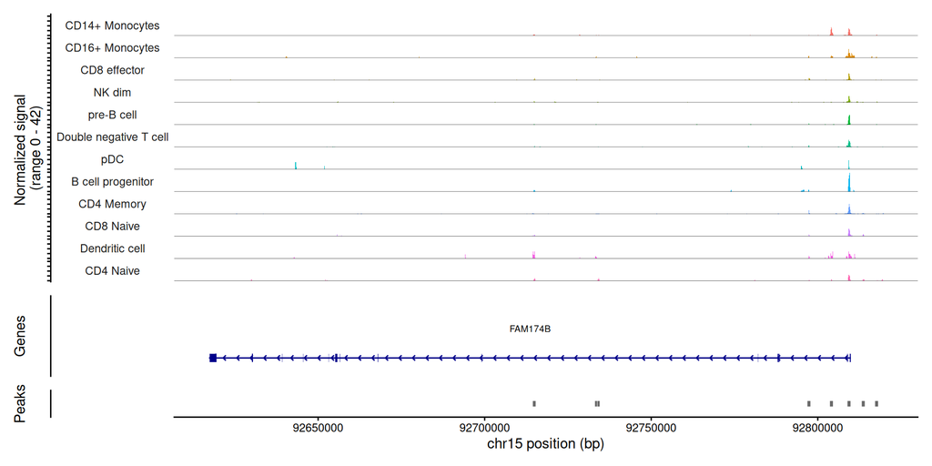

## Lets plot the peak directly

Instead of specifying the gene as a region, we can specify a peak. We will subset our da_peaks to the TRPV4 peak and give that to CoveragePlot.

```r
top_peak <- closest$query_region[closest$gene_name == "TRPV4"][1]

CoveragePlot(
  object            = pbmc,
  region            = top_peak,
  extend.upstream   = 1000,
  extend.downstream = 1000
)
```

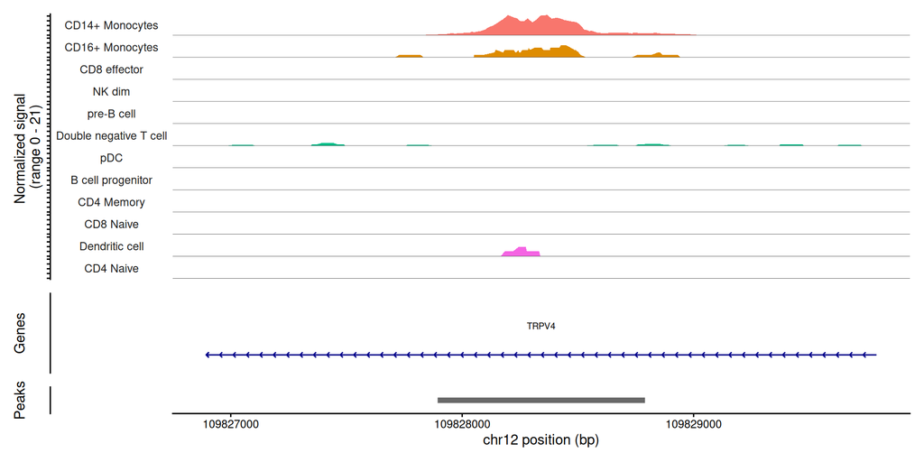

## Lets check known quantity

For comparison lets check a known quantity: IL1B is a known to be highest in CD14+ Monocytes, but also CD16+ Monocytes and Dendritic cells. This matches the scATAC.

```r
CoveragePlot(
  object           = pbmc,
  region           = "IL1B",
  expression.assay = "RNA",
  extend.upstream   = 500,
  extend.downstream = 10000
)
```

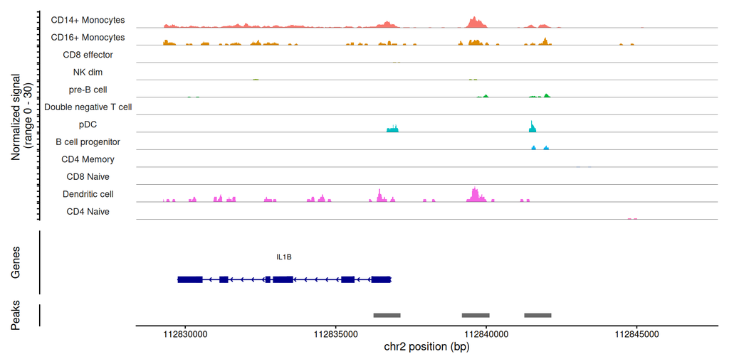

# QC and Markers

## QC and Markers

We have reviewed how we use markers as an additional level of QC with Gene Activity in the last session. Using DA peaks works in the same way.

At this point I would feel happy with the CD14+ Monocyte annotation. A similar review of other markers for other cell types could help. You can also do this at the cluster level to see if the clusters line up.

Always keep in mind the QC. No matter how late you are in the analysis process you could get indicators of a QC issue, which would prompt you to go back and tweak.

## QC and Markers

What to look for as a QC issues is similar to scRNAseq:

- Non-specific markers
- Uncharacterized markers, markers on non-standard chromosomes/sex chromosomes
- Stress related markers
- Housekeeping related markers
- Markers with low log2FC or driven by very few cells

## Finding All Cluster Markers

It’s easy to expand finding markers to all Cell Types using FindAllMarkers. This will run FindMarkers, for every group within Idents.

**Warning**

**We will not run this chunk in class.** Logistic regression on every peak for every cell type takes around 40 minutes. To follow along, load the pre-computed result instead: `all_markers <- readRDS("data/all_markers_pbmc500.rds")`

```r
all_markers <- FindAllMarkers(
  object      = pbmc,
  only.pos    = TRUE,
  test.use    = "LR",
  latent.vars = "nCount_peaks"
)
```

```r
head(all_markers)
```

```
                                 p_val avg_log2FC pct.1 pct.2    p_val_adj
chr6-44058475-44059214    4.212500e-35   4.312910 0.626 0.042 2.596501e-30
chr20-50274658-50275567   4.124875e-34   4.352985 0.626 0.049 2.542490e-29
chr15-92803653-92804551   1.131537e-33   4.751847 0.538 0.028 6.974565e-29
chr12-109827894-109828790 4.226383e-33   4.868226 0.544 0.028 2.605058e-28
chr2-112839190-112840108  8.650538e-32   4.119971 0.538 0.045 5.332019e-27
chr22-30270592-30271507   5.489702e-30   4.570531 0.427 0.024 3.383743e-25
                                  cluster                      gene
chr6-44058475-44059214    CD14+ Monocytes    chr6-44058475-44059214
chr20-50274658-50275567   CD14+ Monocytes   chr20-50274658-50275567
chr15-92803653-92804551   CD14+ Monocytes   chr15-92803653-92804551
chr12-109827894-109828790 CD14+ Monocytes chr12-109827894-109828790
chr2-112839190-112840108  CD14+ Monocytes  chr2-112839190-112840108
chr22-30270592-30271507   CD14+ Monocytes   chr22-30270592-30271507
```

## Finding All Cluster Markers

We can quickly parse these result with dplyr to just grab our top hits for each cell type.

```r
library(dplyr)
top2 <- all_markers |>
  group_by(cluster) |>
  slice_max(order_by = avg_log2FC, n = 2)

head(top2)
```

```
# A tibble: 6 × 7
# Groups:   cluster [3]
     p_val avg_log2FC pct.1 pct.2 p_val_adj cluster         gene
     <dbl>      <dbl> <dbl> <dbl>     <dbl> <fct>           <chr>
1 3.99e-18      12.2  0.234 0      2.46e-13 CD14+ Monocytes chr7-75951266-75952…
2 6.52e-15      12.0  0.187 0      4.02e-10 CD14+ Monocytes chr1-180150713-1801…
3 5.29e- 7       5.17 0.417 0.011  3.26e- 2 CD16+ Monocytes chr3-16704644-16705…
4 2.35e- 5       5.11 0.333 0.009  1   e+ 0 CD16+ Monocytes chr15-50163505-5016…
5 4.29e-13       6.10 0.32  0.005  2.65e- 8 CD8 effector    chr2-201655861-2016…
6 9.34e- 6       5.89 0.16  0.002  5.76e- 1 CD8 effector    chr3-111712069-1117…
```

## Reviewing Cluster Markers

As we did for the single cluster marker results, we can visualize our differentials using Coverage Plots. We can also go back to FeaturePlots and VlnPlots to assess how specific these peaks are.

DotPlot is another very useful function to review multiple markers.

```r
library(ggplot2)
DotPlot(pbmc,top2$gene)+
  theme(axis.text.x = element_text(angle = 45, hjust = 1, size = 8 ))
```

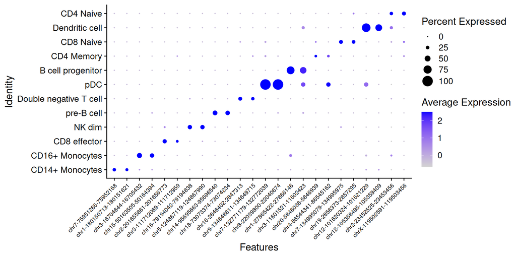

# Pseudobulk differential accessibility

## The Problem of Pseudoreplication

`FindMarkers()` treats each **cell** as an independent observation. But cells from the same **donor or biological context** are highly correlated — they share genetic background, environment, and batch effects. In large datasets you also have a very large n number, so you can reach significance easily, even if changes are subtle.

When comparing conditions (patient vs. control) this leads to **pseudoreplication** — inflated degrees of freedom and many false positives.

## We Need a Second Sample

Pseudobulk treats each **sample** as one replicate, so we need more than our single PBMC 500 sample. We will add a second human PBMC dataset: the ATAC part of the **10x Multiome PBMC (10k)** dataset, available through the [SeuratData](https://github.com/satijalab/seurat-data) package as `pbmcMultiome`.

- Already QC filtered and cell type annotated by the Satija lab
- Downsampled to 1,000 cells to keep things quick
- Passed through the same TSS enrichment and nucleosome signal filters as our data

Combining two samples takes a few extra steps, which we walk through next. They take a while to run, so we have run them for you and provide the final object.

```r
options(timeout = 600)
download.file(
  url      = "https://www.dropbox.com/scl/fi/qavpfxt969y4j9fl9e4x9/pbmc_integrated.rds?rlkey=bwwxg3s55a31o2o15yp1gx73g&st=25qa5j3z&dl=1",
  destfile = "data/pbmc_integrated.rds",
  mode     = "wb"
)
```

## Harmonizing Cell Type Labels

The two samples were labelled with different references, so the same cells have different names, e.g. “CD14+ Monocytes” vs “CD14 Mono”. Pseudobulk compares the **same cell type across samples**, so we first map both onto one shared set of labels.

We collapse to the level both references support, e.g. CD4 TCM, CD4 TEM and Treg all become “CD4 Memory”.

## Harmonizing Cell Type Labels

Every label in either sample gets an entry. Labels with no counterpart in the other sample (HSPC, Plasma, Platelet) map to `NA` and are dropped.

```r
celltype_map <- c(
  # Multiome (seurat_annotations)
  "CD14 Mono"      = "CD14+ Monocytes",
  "CD16 Mono"      = "CD16+ Monocytes",
  "CD4 Naive"      = "CD4 Naive",
  "CD4 TCM"        = "CD4 Memory",
  "CD4 TEM"        = "CD4 Memory",
  "Treg"           = "CD4 Memory",
  "CD8 Naive"      = "CD8 Naive",
  "CD8 TEM_1"      = "CD8 effector",
  "CD8 TEM_2"      = "CD8 effector",
  "NK"             = "NK",
  "Naive B"        = "B",
  "Intermediate B" = "B",
  "Memory B"       = "B",
  "cDC"            = "Dendritic cell",
  "pDC"            = "pDC",
  "gdT"            = "Other T",
  "MAIT"           = "Other T",
  "HSPC"           = NA,
  "Plasma"         = NA,
  # PBMC 500 (predicted.id from the 10k reference)
  "CD14+ Monocytes"        = "CD14+ Monocytes",
  "CD16+ Monocytes"        = "CD16+ Monocytes",
  "CD4 Memory"             = "CD4 Memory",
  "CD8 effector"           = "CD8 effector",
  "NK dim"                 = "NK",
  "NK bright"              = "NK",
  "pre-B cell"             = "B",
  "B cell progenitor"      = "B",
  "Dendritic cell"         = "Dendritic cell",
  "Double negative T cell" = "Other T",
  "Platelet"               = NA
)

multi$celltype <- unname(celltype_map[multi$seurat_annotations])
pbmc$celltype  <- unname(celltype_map[pbmc$predicted.id])
```

## Building a Shared Peak Set

Each sample had its peaks called separately, so the two peak sets do not line up. Before we can compare them, both samples need to be counted on **the same features**.

We take the union of both peak sets and merge any that overlap. Very narrow or very wide merged regions are dropped.

```r
peaks_500   <- read.table("data/atac_pbmc_500_nextgem_peaks.bed",
                          col.names = c("chr", "start", "end"))
peaks_500   <- makeGRangesFromDataFrame(peaks_500)
peaks_multi <- granges(multi[["peaks"]])

combined_peaks <- reduce(c(peaks_500, peaks_multi))
combined_peaks <- combined_peaks[width(combined_peaks) > 20 &
                                 width(combined_peaks) < 10000]
```

## Re-counting Each Sample

We then count each sample’s fragments in the shared peaks, straight from its own fragment file, and build a new Signac object for each.

```r
# PBMC 500
counts_500 <- FeatureMatrix(
  fragments = Fragments(pbmc),
  features  = combined_peaks,
  cells     = colnames(pbmc)
)

obj_500 <- CreateSeuratObject(
  counts    = CreateChromatinAssay(counts     = counts_500,
                                   fragments  = Fragments(pbmc),
                                   annotation = Annotation(pbmc)),
  assay     = "peaks",
  meta.data = pbmc[[]]
)

# PBMC Multiome
counts_multi <- FeatureMatrix(
  fragments = Fragments(multi),
  features  = combined_peaks,
  cells     = colnames(multi)
)

obj_multi <- CreateSeuratObject(
  counts    = CreateChromatinAssay(counts     = counts_multi,
                                   fragments  = Fragments(multi),
                                   annotation = Annotation(pbmc)),
  assay     = "peaks",
  meta.data = multi[[]]
)
```

## Merging the Samples

With both samples on the same peaks, we can merge them. Both use 10x barcodes ending in “-1”, so we add a prefix to keep every cell name unique.

```r
combined <- merge(obj_500, y = obj_multi,
                  add.cell.ids = c("pbmc500", "multiome"))

combined <- RunTFIDF(combined)
combined <- FindTopFeatures(combined, min.cutoff = 10)
combined <- RunSVD(combined, seed.use = 42)
combined <- RunUMAP(combined, reduction = "lsi", dims = 2:30, seed.use = 42,
                    reduction.name = "umap_unintegrated")
```

## Sample Effects Before Integration

Lets load the combined object and look at the UMAP before any integration. You can download it from [here](https://www.dropbox.com/scl/fi/qavpfxt969y4j9fl9e4x9/pbmc_integrated.rds?rlkey=bwwxg3s55a31o2o15yp1gx73g&st=25qa5j3z&dl=1)

```r
pbmc_int <- readRDS("data/pbmc_integrated.rds")
pbmc_int
```

```
An object of class Seurat
106894 features across 1387 samples within 1 assay
Active assay: peaks (106894 features, 0 variable features)
 2 layers present: counts, data
 4 dimensional reductions calculated: integrated_lsi, lsi, umap_unintegrated, umap
```

```r
table(pbmc_int$celltype, pbmc_int$sample)
```

```
                  pbmc_multiome pbmc500
  B                          81      41
  CD14+ Monocytes           251     171
  CD16+ Monocytes            40      12
  CD4 Memory                148      56
  CD4 Naive                 137      17
  CD8 effector               59      49
  CD8 Naive                 114      41
  Dendritic cell             13       5
  NK                         48      27
  Other T                    30      36
  pDC                         8       3
```

## Sample Effects Before Integration

Each cell type splits into two groups, one per sample. Differences between samples, here different 10x technologies, donors and processing, dominate the embedding.

```r
DimPlot(pbmc_int, reduction = "umap_unintegrated",
        group.by = c("sample", "celltype"), label = TRUE, repel = TRUE)
```

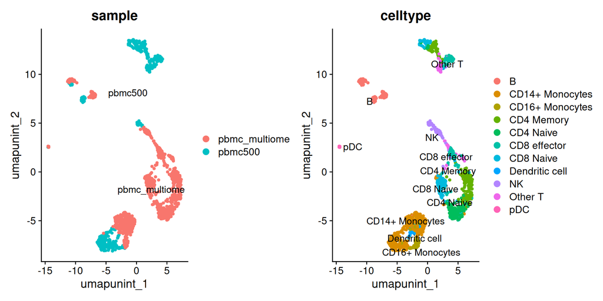

## Multiomic data

As a quick aside these datasets are not great replicates. Multiomic data is much poorer data in general, as you can see here. That said despite these clear QC differnces the cell type signature is very strong.

```r
VlnPlot(pbmc_int, "TSS.enrichment", split.by = "sample")
```

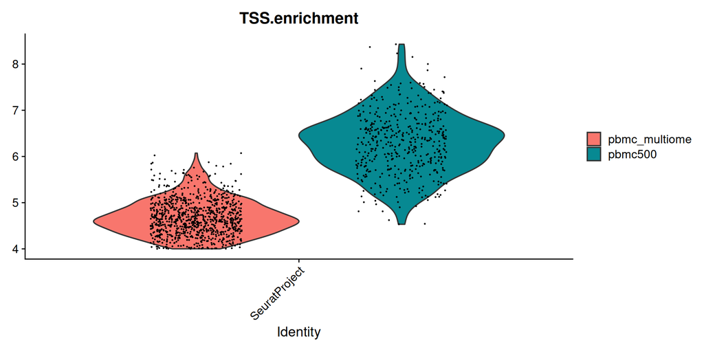

## Integrating with Reciprocal LSI

Signac’s recommended approach projects each sample into the others LSI space to find **anchors**: pairs of matching cells across samples. These are then used to correct the shared LSI embedding. This is similar to what we do with label transfer, but is specific to the lsi space of scATAC.

```r
obj_list <- SplitObject(combined, split.by = "sample")
obj_list <- lapply(obj_list, function(x) {
  x <- FindTopFeatures(x, min.cutoff = 10)
  x <- RunTFIDF(x)
  RunSVD(x, seed.use = 42)
})

anchors <- FindIntegrationAnchors(
  object.list     = obj_list,
  anchor.features = rownames(combined),
  reduction       = "rlsi",
  dims            = 2:30
)

combined <- IntegrateEmbeddings(
  anchorset          = anchors,
  reductions         = combined[["lsi"]],
  new.reduction.name = "integrated_lsi",
  dims.to.integrate  = 1:30
)

combined <- RunUMAP(combined, reduction = "integrated_lsi",
                    dims = 2:30, seed.use = 42)
```

## After Integration

The samples now overlap, and cells group by cell type rather than by sample.

```r
DimPlot(pbmc_int, reduction = "umap",
        group.by = c("sample", "celltype"), label = TRUE, repel = TRUE)
```

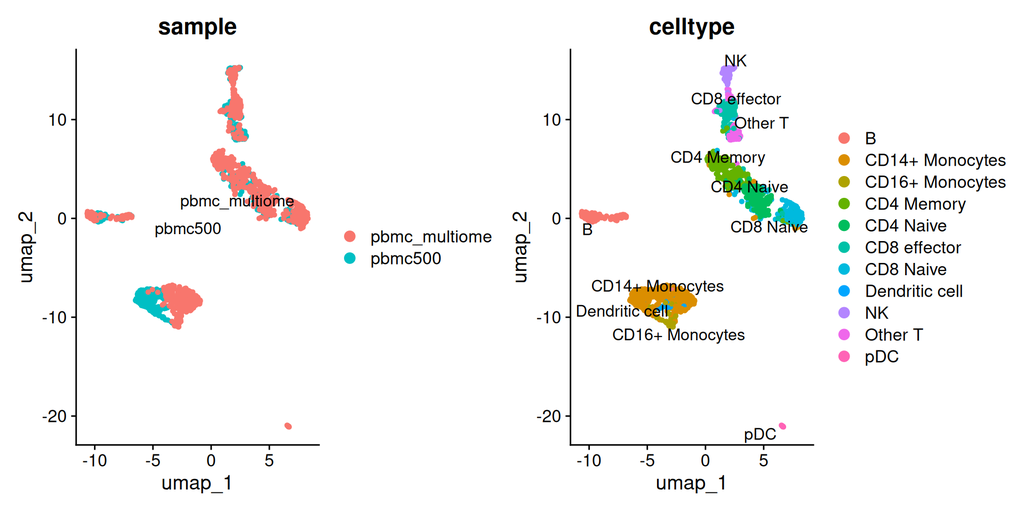

## What Integration Does (and Doesn’t) Change

Integration only corrects the **low-dimensional embedding** (`integrated_lsi`) used for UMAP, clustering and label transfer. The **peak counts are untouched**.

- Use the embedding to visualize and cluster across samples
- Use the **raw counts** for differential accessibility, with sample accounted for in the model

This is exactly what pseudobulk needs: we sum the original counts per cell type and sample, and let DESeq2 handle the differences between samples.

## Pseudobulk Workflow

**Pseudobulk analysis:**

1. Aggregate (sum) counts within each cell type × sample combination
2. Treat each aggregated profile as one bulk sample
3. Run bulk DA tools (DESeq2, edgeR) on the aggregates

We now have some replicates to be able to do this.

We will use DESeq2. Some folks prefer EdgeR. In our hands they perform similarly.

```r
library(DESeq2)

bulk <- AggregateExpression(
  pbmc_int,
  assays       = "peaks",
  return.seurat = FALSE,
  group.by     = c("celltype","sample")
)

counts_bulk <- bulk$peaks
head(counts_bulk)
```

```
6 x 22 sparse Matrix of class "dgCMatrix"
```

```
chr1-10109-10357   3 . 1 1 1 . 1 2 1 . . 2 . 1 . . . . 1 3 . .
chr1-180629-181630 . . 2 1 1 . 5 5 4 1 . 2 . 3 1 . 1 . . . . .
chr1-191491-191736 . . 3 2 . . 1 . 1 . . 1 . . . . . . . 1 . .
chr1-267816-268196 . 1 4 2 . 1 3 1 1 . . 1 1 . . . . . . 1 . .
chr1-586028-586373 1 . 4 . . . 1 . 1 . 1 . 1 1 . . . . . . . .
chr1-629503-630399 5 1 4 2 1 1 2 1 4 . 2 1 6 3 . . . . 1 1 . .
```

## DESeq2 DA Analysis

Now we have our input matrix we can start our DA analysis. First we need a metadata object.

```r
parts <- do.call(rbind, strsplit(colnames(counts_bulk), "_"))

col_data <- data.frame(
  celltype  = parts[, 1],
  sample    = parts[, 2],
  row.names = colnames(counts_bulk)
)

# How many cells went into each pseudobulk. AggregateExpression turns "_"
# inside a value into "-", so match that when building the group names.
pb_group <- paste(pbmc_int$celltype, gsub("_", "-", pbmc_int$sample), sep = "_")
col_data$n_cells <- as.vector(table(pb_group)[rownames(col_data)])
col_data
```

```
                                     celltype        sample n_cells
B_pbmc-multiome                             B pbmc-multiome      81
B_pbmc500                                   B       pbmc500      41
CD14+ Monocytes_pbmc-multiome CD14+ Monocytes pbmc-multiome     251
CD14+ Monocytes_pbmc500       CD14+ Monocytes       pbmc500     171
CD16+ Monocytes_pbmc-multiome CD16+ Monocytes pbmc-multiome      40
CD16+ Monocytes_pbmc500       CD16+ Monocytes       pbmc500      12
CD4 Memory_pbmc-multiome           CD4 Memory pbmc-multiome     148
CD4 Memory_pbmc500                 CD4 Memory       pbmc500      56
CD4 Naive_pbmc-multiome             CD4 Naive pbmc-multiome     137
CD4 Naive_pbmc500                   CD4 Naive       pbmc500      17
CD8 effector_pbmc-multiome       CD8 effector pbmc-multiome      59
CD8 effector_pbmc500             CD8 effector       pbmc500      49
CD8 Naive_pbmc-multiome             CD8 Naive pbmc-multiome     114
CD8 Naive_pbmc500                   CD8 Naive       pbmc500      41
Dendritic cell_pbmc-multiome   Dendritic cell pbmc-multiome      13
Dendritic cell_pbmc500         Dendritic cell       pbmc500       5
NK_pbmc-multiome                           NK pbmc-multiome      48
NK_pbmc500                                 NK       pbmc500      27
Other T_pbmc-multiome                 Other T pbmc-multiome      30
Other T_pbmc500                       Other T       pbmc500      36
pDC_pbmc-multiome                         pDC pbmc-multiome       8
pDC_pbmc500                               pDC       pbmc500       3
```

## DESeq2 DA Analysis

Now lets run DESeq2. We need to provide all the count and metadata information to create our DESeq object. We are also going to include Sample as a covariate in our model. We know that Sample will have a big impact in this dataset, but in others this may not be necessary.

```r
# Pseudobulks summed from only a few cells are mostly noise, and DESeq2 shares
# its variance estimates across all columns, so drop them before fitting
keep_cols   <- col_data$n_cells >= 10
counts_keep <- counts_bulk[, keep_cols]
col_keep    <- col_data[keep_cols, ]

dds <- DESeqDataSetFromMatrix(
  countData = counts_keep,
  colData   = col_keep,
  design    = ~ sample + celltype   # sample is the replicate/blocking factor
)
dds <- DESeq(dds)
```

## DESeq2 Results

We can now call results to get the differential from an individual comparison.

```r
res_deseq <- results(dds, contrast = c("celltype", "CD14+ Monocytes", "B"))
summary(res_deseq, alpha = 0.05)
```

```
out of 106855 with nonzero total read count
adjusted p-value < 0.05
LFC > 0 (up)       : 4841, 4.5%
LFC < 0 (down)     : 2863, 2.7%
outliers [1]       : 0, 0%
low counts [2]     : 66292, 62%
(mean count < 2)
[1] see 'cooksCutoff' argument of ?results
[2] see 'independentFiltering' argument of ?results
```

## Lets compare to findMarkers

```r
Idents(pbmc_int) <- "celltype"
res_fm <- FindMarkers(pbmc_int, ident.1 = "CD14+ Monocytes", ident.2 = "B")
```

## Comparing the Results

```r
pb_sig <- rownames(res_deseq)[which(res_deseq$padj < 0.05)]
fm_sig <- rownames(res_fm)[res_fm$p_val_adj < 0.05]

data.frame(
  approach    = c("Pseudobulk (DESeq2)", "FindMarkers (per cell)"),
  significant = c(length(pb_sig), length(fm_sig)),
  in_both     = length(intersect(pb_sig, fm_sig)),
  # typical strength of evidence among the peaks each approach calls
  median_padj_significant = c(median(res_deseq[pb_sig, "padj"]),
                              median(res_fm[fm_sig, "p_val_adj"])),
  min_padj = c(min(res_deseq[pb_sig, "padj"]),
                              min(res_fm[fm_sig, "p_val_adj"]))
)
```

```
                approach significant in_both median_padj_significant
1    Pseudobulk (DESeq2)        7704    3937            5.200592e-03
2 FindMarkers (per cell)        7086    3937            1.188513e-05
      min_padj
1 1.056336e-32
2 2.372074e-76
```

- Monocytes and B cells differ so much that both approaches find thousands of peaks. Many of these overlap, but there are plenty of peaks that are specific to the approach used.
- For FindMarkers the per-cell p-values are more extreme, because each cell is counted as an independent replicate.

## Example: FindMarkers Only

That is not all the differences.

```r
CoveragePlot(
  object            = pbmc_int,
  region            = "chr6-106702055-106703095",
  group.by          = "celltype",
  split.by          = "sample",
  idents            = c("CD14+ Monocytes", "B"),
  extend.upstream   = 2000,
  extend.downstream = 2000
)
```

[output not shown]

Open in B cells in **both** samples, absent in monocytes. The per-cell test is very confident. Pseudobulk is not: the peak has signal in only 2 of the pseudobulks, so DESeq2 cannot estimate its variance well, and its average count is low enough that DESeq2’s independent filtering may not test it at all (`padj` is `NA`). This one is probably real: per-cell tests are not always wrong, but pseudobulk only calls what it can back with sample-level evidence.

## Example: Pseudobulk Only

```r
CoveragePlot(
  object            = pbmc_int,
  region            = "chr6-41934567-41943790",
  group.by          = "celltype",
  split.by          = "sample",
  idents            = c("CD14+ Monocytes", "B"),
  extend.upstream   = 2000,
  extend.downstream = 2000
)
```

[output not shown]

Open in both cell types, so the per-cell contrast is weak. But summed across cells it is consistently higher in monocytes in **both** samples, which pseudobulk can detect with confidence.

## FindMarkers vs Pseudobulk

To recap there are key differences and restrictions for differential methods.

|  | `FindMarkers()` (per cell) | Pseudobulk (DESeq2 / edgeR) |
| --- | --- | --- |
| Unit of replication | Each **cell** | Each **sample** |
| Needs replicates? | No | Yes, ideally 3+ per group |
| Sample/donor effects | Ignored | Modeled (`~ sample + celltype`) |
| p-values | Over-confident with many cells | Reflect sample-level variation |
| Best for | Exploring markers within one sample | Comparisons you want to generalize beyond your samples |

The difference matters most for **subtle effects**, e.g. patient vs control within one cell type. There, sample-to-sample variation is as large as the effect itself, and per-cell tests produce many false positives.

## Other Approaches

**Other pseudobulk tools**

- edgeR (quasi-likelihood) and limma-voom: same idea as DESeq2, with different models for the variance

**Mixed models**

- Keep the single cells, but add sample/donor as a **random effect**, e.g. NEBULA, glmmTMB, or the mixed-model options in muscat
- They account for pseudoreplication like pseudobulk does (Zimmerman *et al*, 2021), but are slower and more complex

**scATAC-specific methods**

- **ArchR** `getMarkerFeatures()`: Wilcoxon test against background cells matched on TSS enrichment and fragment counts
- **chromVAR**: tests at the level of TF motifs rather than single peaks
- **Count-based models** that treat fragment counts as quantitative (e.g. Martens *et al*, 2024) rather than binary

For a benchmark of these methods on scATAC data, see [Teo, Squair & Courtine, 2024](https://doi.org/10.1038/s41467-024-53089-5).

# Where to Go Next

## Next Steps: Motifs

- **Interpreting DA peaks**
  - Annotate peaks to genes and genomic features with [ChIPseeker](https://bioconductor.org/packages/ChIPseeker/)
  - Test for functional enrichment of nearby genes with [rGREAT](https://bioconductor.org/packages/rGREAT/) and [clusterProfiler](https://bioconductor.org/packages/release/bioc/html/clusterProfiler.html)
- **Motifs**
  - Signac [`FindMotifs()`](https://stuartlab.org/signac/articles/motif_vignette): which TF motifs are enriched in a set of peaks, e.g. your DA peaks
  - [chromVAR](https://bioconductor.org/packages/chromVAR/) (`RunChromVAR()`): a per-cell accessibility score for each TF motif, which you can then compare between groups
  - Signac [`Footprint()`](https://stuartlab.org/signac/articles/footprint): TF footprinting at motif sites, to look for evidence of binding

## Next Steps: Regulation and Beyond

- **Multiome data**
  - Seurat [WNN](https://satijalab.org/seurat/articles/weighted_nearest_neighbor_analysis) (`FindMultiModalNeighbors()`): cluster using RNA and ATAC together
  - Signac [`LinkPeaks()`](https://stuartlab.org/signac/articles/pbmc_multiomic): link peaks to genes by correlating accessibility with expression in the same cells
- **Gene regulation**
  - [Cicero](https://cole-trapnell-lab.github.io/cicero-release/): links regulatory regions (e.g. enhancers to promoters) by co-accessibility. Works on scATAC alone
  - [Epiregulon](https://bioconductor.org/packages/epiregulon/): TF activity per cell. Needs gene expression too, from multiome or from a separate scRNA-seq dataset integrated with your ATAC data
  - [SCENIC+](https://github.com/aertslab/scenicplus): regulatory networks from paired accessibility and expression
- **Trajectories**
  - [Monocle 3](https://cole-trapnell-lab.github.io/monocle3/), which Cicero builds on, or [ArchR’s trajectory tools](https://www.archrproject.com/bookdown/trajectory-analysis-with-archr.html), to order cells along a differentiation path

## Course Summary

**Session 1 — Foundations**

- Chromatin accessibility biology; why sparsity is the defining challenge
- scATAC-seq technologies; fragment files, count matrices
- Loading data into Signac/Seurat; gene annotations

**Session 2 — QC & Preprocessing**

- TSS enrichment, nucleosome signal, FRiP, blacklist ratio
- Iterative threshold-setting and filtering
- TF-IDF normalization; `FindTopFeatures()`

**Session 3 — Dimensionality Reduction & Clustering**

- LSI via `RunSVD()`; always skip component 1 (`DepthCor()`)
- UMAP; graph-based clustering; tuning resolution
- QC as a cyclical process; gene activity; label transfer

**Session 4 — Differential Accessibility & Visualization**

- `FindMarkers()` with logistic regression + depth covariate
- Pseudobulk approaches with DESeq2/edgeR
- `CoveragePlot()` directly from the fragment file
- Motif analysis, multi-modal integration, pseudotime, regulatory networks

## Further Resources

| Resource | URL |
| --- | --- |
| Signac documentation | https://stuartlab.org/signac/ |
| Seurat documentation | https://satijalab.org/seurat/ |
| ArchR | https://www.archrproject.com/ |
| snapATAC2 | https://github.com/scverse/SnapATAC2 |
| 10x Genomics ATAC datasets | https://www.10xgenomics.com/datasets |

**Questions?** Contact the Bioinformatics Resource Center at **brc@rockefeller.edu**

## Time for an exercise!

Exercise on differential accessibility and visualization can be found here

## Answers to exercise.

Answers can be found here